# Exercise Prediction

Poobalan

December 23, 2015

### Loading Data and Libraries

Two sets of data is loaded. training consist of data used for training and validating the model, while testing is used for prediction.

```r
training <- read.csv("pml-training.csv",na.strings = c("NA","#DIV/0!", ""))
testing <- read.csv("pml-testing.csv")
```

### Data Exploration

```r
str(training)
```

```
## 'data.frame':    19622 obs. of  160 variables:
##  $ X                       : int  1 2 3 4 5 6 7 8 9 10 ...
##  $ user_name               : Factor w/ 6 levels "adelmo","carlitos",..: 2 2 2 2 2 2 2 2 2 2 ...
##  $ raw_timestamp_part_1    : int  1323084231 1323084231 1323084231 1323084232 1323084232 1323084232 1323084232 1323084232 1323084232 1323084232 ...
##  $ raw_timestamp_part_2    : int  788290 808298 820366 120339 196328 304277 368296 440390 484323 484434 ...
##  $ cvtd_timestamp          : Factor w/ 20 levels "02/12/2011 13:32",..: 9 9 9 9 9 9 9 9 9 9 ...
##  $ new_window              : Factor w/ 2 levels "no","yes": 1 1 1 1 1 1 1 1 1 1 ...
##  $ num_window              : int  11 11 11 12 12 12 12 12 12 12 ...
##  $ roll_belt               : num  1.41 1.41 1.42 1.48 1.48 1.45 1.42 1.42 1.43 1.45 ...
##  $ pitch_belt              : num  8.07 8.07 8.07 8.05 8.07 8.06 8.09 8.13 8.16 8.17 ...
##  $ yaw_belt                : num  -94.4 -94.4 -94.4 -94.4 -94.4 -94.4 -94.4 -94.4 -94.4 -94.4 ...
##  $ total_accel_belt        : int  3 3 3 3 3 3 3 3 3 3 ...
##  $ kurtosis_roll_belt      : num  NA NA NA NA NA NA NA NA NA NA ...
##  $ kurtosis_picth_belt     : num  NA NA NA NA NA NA NA NA NA NA ...
##  $ kurtosis_yaw_belt       : logi  NA NA NA NA NA NA ...
```

[output cut: 86 more lines]

```r
summary(training)
```

[output not shown]

[output cut: 313 more lines]

[output not shown]

### Data Cleaning

```r
training$kurtosis_roll_belt <- as.numeric(training$kurtosis_roll_belt)
training$kurtosis_picth_belt <- as.numeric(training$kurtosis_picth_belt)
training$kurtosis_yaw_belt <- as.numeric(training$kurtosis_yaw_belt)
training$skewness_roll_belt <- as.numeric(training$skewness_roll_belt)
training$skewness_roll_belt.1 <- as.numeric(training$skewness_roll_belt.1)
training$skewness_yaw_belt <- as.numeric(training$skewness_yaw_belt)
training$max_yaw_belt <- as.numeric(training$max_yaw_belt)
training$amplitude_yaw_belt <- as.numeric(training$amplitude_yaw_belt)
training$kurtosis_roll_arm <- as.numeric(training$kurtosis_roll_arm)
training$kurtosis_picth_arm <- as.numeric(training$kurtosis_picth_arm)
training$kurtosis_yaw_arm <- as.numeric(training$kurtosis_yaw_arm)
training$skewness_roll_arm <- as.numeric(training$skewness_roll_arm)
training$skewness_picth_arm <- as.numeric(training$skewness_pitch_arm)
training$skewness_yaw_arm <- as.numeric(training$skewness_yaw_arm)
training$kurtosis_roll_dumbbell <- as.numeric(training$kurtosis_roll_dumbbell)
training$kurtosis_picth_dumbbell <- as.numeric(training$kurtosis_picth_dumbbell)
training$kurtosis_yaw_dumbbell <- as.numeric(training$kurtosis_yaw_dumbbell)
training$skewness_roll_dumbbell <- as.numeric(training$skewness_roll_dumbbell)
training$skewness_pitch_dumbbell <- as.numeric(training$skewness_pitch_dumbbell)
training$skewness_yaw_dumbbell <- as.numeric(training$skewness_yaw_dumbbell)
training$max_yaw_dumbbell <- as.numeric(training$max_yaw_dumbbell)
training$min_yaw_dumbbell <- as.numeric(training$min_yaw_dumbbell)
training$min_yaw_belt <- as.numeric(training$min_yaw_belt)
training$classe <- as.factor(training$classe)
```

Secondly, irrelevant columns are removed (first seven columns in the dataset).

```r
training.cols.removed <- training[,-(1:7)]
```

Thirdly, columns that have high percentage of NAs are removed. For this exercise, any column with NAs comprising more than 2.5% of the data is removed.

```r
limit <- 0.025 * nrow(training.cols.removed) #limit for NA is 2.5%
training.na.removed <- training.cols.removed[, which(as.numeric(colSums(is.na(training.cols.removed)))<limit)]
```

The cleaned training dataset is created:

```r
training.clean <- training.na.removed
```

Comparing distribution of **classe** before and after cleaning shows no difference, meaning the cleaning process did not affect the number of rows.

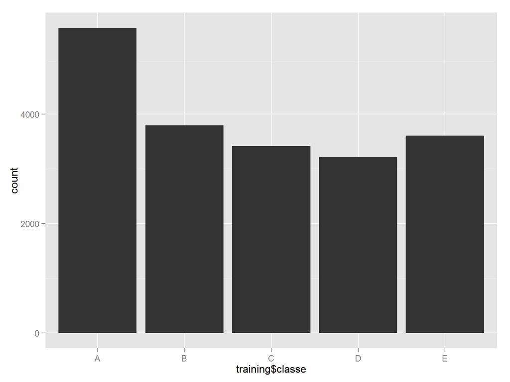

```r
qplot(training$classe, geom="histogram")
```

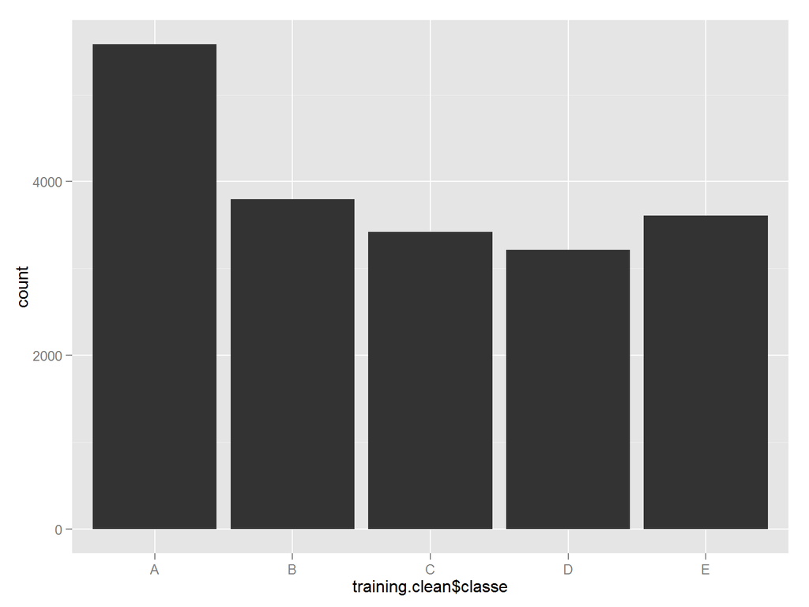

```r
qplot(training.clean$classe, geom="histogram")
```

### Training and Validation Set

The cleaned training set is split into **traindata** and **validatedata** at 60/40 ratio.

```r
inTrain <- createDataPartition(y=training.clean$classe, p=0.6,list=FALSE)
traindata <- training.clean[inTrain, ]
validatedata <- training.clean[-inTrain,]
```

### Model Training

For the purpose of this exercise, *random forest* method is used to train the model. Random forest classification method is among the top two performing algorithms in prediction contests, thus is chosen for this exercise.

```r
modelFitrf <- train(classe ~ ., data=traindata, method="rf", trControl = trainControl(method="oob",allowParallel = TRUE))
modelFitrf
```

```
## Random Forest
##
## 11776 samples
##    52 predictor
##     5 classes: 'A', 'B', 'C', 'D', 'E'
##
## No pre-processing
## Resampling results across tuning parameters:
##
##   mtry  Accuracy   Kappa
##    2    0.9912534  0.9889352
##   27    0.9912534  0.9889361
##   52    0.9878567  0.9846385
##
## Accuracy was used to select the optimal model using  the largest value.
## The final value used for the model was mtry = 2.
```

```r
modelFitrf$finalModel
```

```
##
## Call:
##  randomForest(x = x, y = y, mtry = param$mtry)
##                Type of random forest: classification
##                      Number of trees: 500
## No. of variables tried at each split: 2
##
##         OOB estimate of  error rate: 0.94%
## Confusion matrix:
##      A    B    C    D    E class.error
## A 3343    3    0    1    1 0.001493429
## B   17 2249   12    0    1 0.013163668
## C    1   17 2033    3    0 0.010223953
## D    1    0   43 1883    3 0.024352332
## E    0    0    2    6 2157 0.003695150
```

Accuracy is **99.125** for mtry=2.

Prediction using the traindata set returns accuracy of 1 (in sample error is 0%).

```r
predictions <- predict(modelFitrf, newdata=traindata)
confusionMatrix(predictions, traindata$classe)
```

```
## Confusion Matrix and Statistics
##
##           Reference
## Prediction    A    B    C    D    E
##          A 3348    0    0    0    0
##          B    0 2279    0    0    0
##          C    0    0 2054    0    0
##          D    0    0    0 1930    0
##          E    0    0    0    0 2165
##
## Overall Statistics
##
##                Accuracy : 1
##                  95% CI : (0.9997, 1)
##     No Information Rate : 0.2843
##     P-Value [Acc > NIR] : < 2.2e-16
##
##                   Kappa : 1
##  Mcnemar's Test P-Value : NA
##
## Statistics by Class:
##
##                      Class: A Class: B Class: C Class: D Class: E
## Sensitivity            1.0000   1.0000   1.0000   1.0000   1.0000
## Specificity            1.0000   1.0000   1.0000   1.0000   1.0000
## Pos Pred Value         1.0000   1.0000   1.0000   1.0000   1.0000
## Neg Pred Value         1.0000   1.0000   1.0000   1.0000   1.0000
## Prevalence             0.2843   0.1935   0.1744   0.1639   0.1838
## Detection Rate         0.2843   0.1935   0.1744   0.1639   0.1838
## Detection Prevalence   0.2843   0.1935   0.1744   0.1639   0.1838
## Balanced Accuracy      1.0000   1.0000   1.0000   1.0000   1.0000
```

The model is validated using the **validatedata** dataset

```r
predictions <- predict(modelFitrf, newdata=validatedata)
confusionMatrix(predictions, validatedata$classe)
```

```
## Confusion Matrix and Statistics
##
##           Reference
## Prediction    A    B    C    D    E
##          A 2227   11    0    0    0
##          B    5 1502    7    0    0
##          C    0    5 1361   22    3
##          D    0    0    0 1260    3
##          E    0    0    0    4 1436
##
## Overall Statistics
##
##                Accuracy : 0.9924
##                  95% CI : (0.9902, 0.9942)
##     No Information Rate : 0.2845
##     P-Value [Acc > NIR] : < 2.2e-16
##
##                   Kappa : 0.9903
##  Mcnemar's Test P-Value : NA
##
## Statistics by Class:
##
##                      Class: A Class: B Class: C Class: D Class: E
## Sensitivity            0.9978   0.9895   0.9949   0.9798   0.9958
## Specificity            0.9980   0.9981   0.9954   0.9995   0.9994
## Pos Pred Value         0.9951   0.9921   0.9784   0.9976   0.9972
## Neg Pred Value         0.9991   0.9975   0.9989   0.9961   0.9991
## Prevalence             0.2845   0.1935   0.1744   0.1639   0.1838
## Detection Rate         0.2838   0.1914   0.1735   0.1606   0.1830
## Detection Prevalence   0.2852   0.1930   0.1773   0.1610   0.1835
## Balanced Accuracy      0.9979   0.9938   0.9951   0.9897   0.9976
```

Based on the accuracy (0.9924) using validation data, the out sample error rate is (1-0.9924)= 0.0076 or **0.76%**.

Using varImp, the importance of the variables in random forest model is displayed.

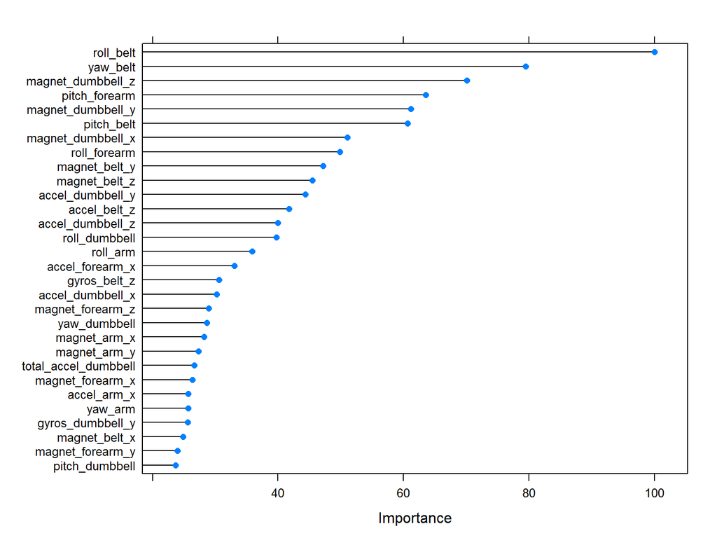

```r
varlist <- varImp(modelFitrf)
plot(varlist,top=30)
```

From the plot above, we can see that less than ten variables have importance more than 50%. Variables more than 50% importance is selected from the training set and pairwise plot is created.

```r
topvars <- subset(varlist$importance,varlist$importance$Overall>50)
sort(topvars$Overall,decreasing=TRUE)
```

```
## [1] 100.00000  79.51394  70.08038  63.56990  61.20365  60.69111  51.05501
```

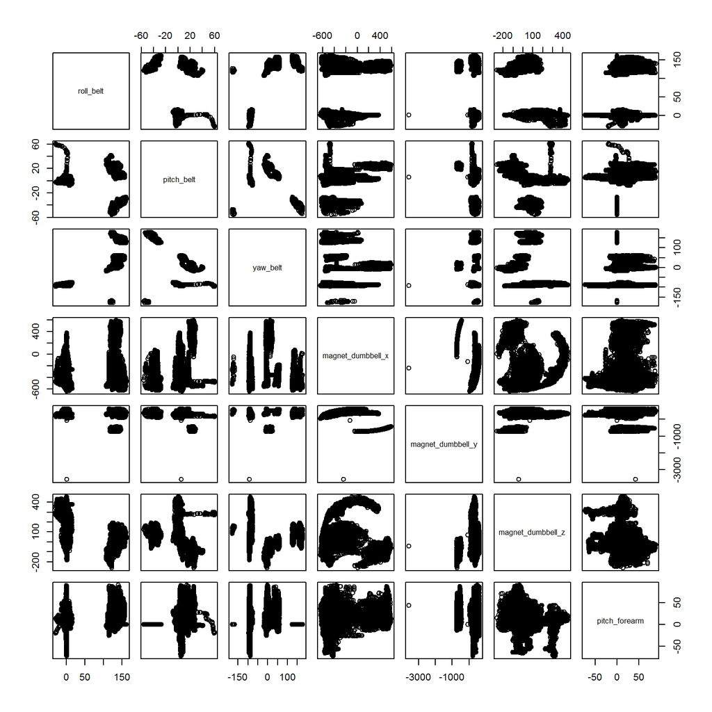

```r
selcols <- training.clean[,c(rownames(topvars))]
pairs(selcols)
```

At total of seven variables were identified.

Variable **magnet_dumbbell_y** seems to have an outlier value and further investigation shows a value of -3600 compared to other values between 633 and -744.

### Prediction

The model is then used to predict the class for each of the 20 observations in the testing dataset. The data is written out using the given function **pml_write_files()**

```r
predictions <- predict(modelFitrf, newdata=testing)

predictions
```

```
##  [1] B A B A A E D B A A B C B A E E A B B B
## Levels: A B C D E
```

```r
pml_write_files = function(x){
  n = length(x)
  for(i in 1:n){
    filename = paste0("problem_id_",i,".txt")
    write.table(x[i],file=filename,quote=FALSE,row.names=FALSE,col.names=FALSE)
  }
}

pml_write_files(predictions)
```

### Summary

1. Random forest algorithm able to predict to high degree of accuracy.
2. Columns with many NAs are removed to improve model.
3. Other variables not provided in dataset may also affect actual prediction but due to limited data available, this is the best can be done.

### Reference

The training data for this project are available here:

https://d396qusza40orc.cloudfront.net/predmachlearn/pml-training.csv

The test data are available here:

https://d396qusza40orc.cloudfront.net/predmachlearn/pml-testing.csv

The data for this project come from this source: http://groupware.les.inf.puc-rio.br/har